# SUM25_River_Rockfish_Proj_V0.3

River Mckegney

2025-07-09

## Setup, and Packages

Code Packages:

```r
# Load packages
library(gridExtra) # For using grid.table to save tables as images
library(flextable) # Alternative method to save df as image
library(tidyverse)
library(zoo)
library(lme4)
library(lmerTest)
library(rlang)
library(nortest) # For ad.test
library(car) # For homogeneity of variance with leveneTest
library(rcompanion) # For scheirerRayHare test
library(pastecs) # For stat.desc
library(ggpubr) # For assumption plots
```

## Intro:

River Mckegney’s CSUMB UROC Innovation Scholars Summer 2025 Research Project. This Research project is about gopher rockfish (*S. Carnatus*) and their physiological response to environmental exposure of low pH and dissolved oxygen, factors mimicking the synergistic effects of ocean acidification and Hypoxic (OAH) climate change stressors. The effects of OAH on *S. carnatus* reproduction will also be investigated.

Gopher Rockfish (*S. carnatus*) are viviparous species, where pregnant females develop often multiple larvae internally, and give live birth during spawing season. Mothers brood in the spring (Jan-May) that coincides with a seasonal upwelling period (Apr-Jun) along the Pacific Northwest, which is known to cause environmental changes to near shore water chemistry involving a decrease in pH (more acidic) and dissolved oxygen concentrations [DO]. These changes may act as synergistic stressors, effecting *S. carnatus* physiology and reproduction. If conditions are not favorable, or energetic demands are too costly, then pregnant *S. carnatus* may reabsorb their eggs and the pregnancy aborted, a process known as atresia.

This study will investigate how *S. carnatus* blood work parameters compare between patients exposed to ambient and OAH treatments (~ treatment groups), and will also look for differences between female gopher rockfish who experience atresia and those who undergo parturition or successful pregnancy (parturition status groups), as well as comparing the two treatments and parturition status groups.

## Award Credits:

This project was funded by the undergraduate CSU-COAST and Jim and Peggy Ryan Marine Science Research Award Program. This project is in association with California State University Monterey Bay UROC Innovation Scholars Summer 2025 Research Program.

## Objective:

The goals of this study are:

## Hypotheses:

The hypotheses of this study are listed below:

Template: 1). response to OAH stress compared to ambient treatment: 2). response to atresia compared to successful parturition: 3). response towards OAH & atresia conditions vs ambient & successful parturition:

**Internal pH**

pH response to OAH stress compared to ambient treatment: Healthy pregnant gopher rockfish are hypothesized to maintain their internal blood pH. Acclimitization to a new stabilized pH setpoint is also possible. Changes to internal pH could indicate compromised metabolic function. Natural change to pH due to pregnancy, and other reproduction related confounding variables could also be considered.

pH response to atresia compared to successful parturition:

pH response towards OAH & atresia conditions vs ambient & successful parturition:

**Glucose**

Glucose response to OAH stress compared to ambient treatment: Internal glucose is expected to increase in response to OAH treatment, as a physiological stress response to the supposed increased environmental stress.

Glucose response to atresia compared to successful parturition: Internal glucose is expected to be greater for *S. carnatus* that experience atresia compared to those who have successful parturition. This is reaction is suspected as a stress response towards metabolic demands of egg reabsorption, and suspected high energetic demands of metabolism (indicated by atresia) stimulating immune response.

Glucose response towards OAH & atresia conditions vs ambient & successful parturition: It is unknown how *S. carnatus* blood glucose levels will compare between individuals who experience OAH treatment and atresia versus those who are exposed to ambient treatment and have successful parturition.

**Hematocrit**

Hematocrit response to OAH stress compared to ambient treatment: The OAH treatment is hypothesized to increase percent hematocrit, as a physiological response to counter low environmental dissolved oxygen concentrations [DO], and meet adequate blood oxygen metabolic demands.

Hematocrit response to atresia compared to successful parturition: Atresia patients are hypothesized to have decreased hematocrit levels in contrast to sucessful parturition *S. carnatus* individuals, because pregnancy (larvae development) is suspected to increase the blood gas demands of maternal individuals, and thus require a boost in gas exchange efficiency.

Hematocrit response towards OAH & successful parturition conditions vs ambient & atresia: Individuals exposed to OAH treatment and have a sucessful pregnancy are hypothesized to have higher hematocrit levels compared to atresia patients in the ambient treatment tank.

**Ions: Sodium, Chloride, Potassium, and Calcium**

**Sodium: Na+**

Sodium response to OAH stress compared to ambient treatment: I suspect internal blood sodium concentrations to increase in response to OAH stress. This is suspected due to the previous studies on acid secretion and NA+ absorption proposed mechanisms (Evans et al. 2005).

Sodium response to atresia compared to successful parturition: This depends on how pregnancy effects natural acid-base and osmoregulatory ion balance. Furthure investigation would be required to assess this potentially confounding idea.

Sodium response towards OAH & atresia conditions vs ambient & successful parturition: The interactive role of parturition and decreased environmental pH & oxygen concentrations on gopher rockfish blood sodium concentration is unknown. Due to a lack of study on the effects of parturition on ion balance it is difficult to predict how this might influence pH change variables. This experiment however could produce useful data in assessing this concept.

**Potassium: K+**

Potassium response to OAH stress compared to ambient treatment: A decrease in potassium levels in response to OAH treatment is hypothesized, due to the stressor inducing mild metabolic acidosis, causing a bulk movement of potassium from intracellular to extracellular spaces, where it may be excreted via diffusion through gills or skin, or lost in fecal waste.

Potassium response to atresia compared to successful parturition:

Potassium response towards OAH & atresia conditions vs ambient & successful parturition:

**Chloride: Cl-**

Chloride response to OAH stress compared to ambient treatment:

Chloride response to atresia compared to successful parturition:

Chloride response towards OAH & atresia conditions vs ambient & successful parturition:

**Calcium: Ca+2**

Calcium response to OAH stress compared to ambient treatment:

Calcium response to atresia compared to successful parturition:

Calcium response towards OAH & atresia conditions vs ambient & successful parturition:

## Works Cited: Citation bibliography

## Special Thanks:

## Experiment: Add in data alaysis here

## Data Entry: Read-in data

```r
# Read and call data into df

# Primary samples df
ABL90 <- read.csv("Raw_Data/ABL90_Raw.csv")

# River's Parturition metadata
partuition_subcat <- read.csv("Raw_Data/River's_Rockfish_Metadata_Parturition_V7.csv")
```

## Data Filtering

```r
# Data sifting: ABL90 dataset

# Step 1: Remove missing info
ABL_set1 <- ABL90 %>%
  filter(Patient.ID_edited != "")


# Step 2: Separate Patient.ID into columns of sample types: blood plasma and instant freeze plasma
ABL_set2 <- separate(ABL_set1, 'Patient.ID_edited', into = c("Patient.ID_edited", "Sample_Type"), sep = ",")
# Step 3:
# Convert Patient.ID_edited column data to character type
ABL_set2$Patient.ID_edited <- as.character(ABL_set2$Patient.ID_edited)

ABL_set3 <- ABL_set2
```

```r
# Step 4
# Assign NA value to only `Errors.detected.during.measurement` column

ABL_set4 <- ABL_set3

# For some reason assigning NAs removes almost all obs (0nly 2 left)

#  ABL_set4 <- ABL_set3 %>%
# mutate(Errors.detected.during.measurement = na_if(Errors.detected.during.measurement, ""))


# Alternative Method: Assign NAs to all character columns
# ABL_set4 <- ABL_set3 %>%
# mutate(across(where(is.character), ~ na_if(., "")))
```

```r
# Step 5 & 6: Sussing out specific sample errors

# Remove insufficient samples
ABL_set5 <- ABL_set4 %>%
  filter(!is.na("Type")) %>%
  filter(!str_detect(Errors.detected.during.measurement, "Insufficient sample"))

# Remove inhomogeneous samples
ABL_set5 <- ABL_set5 %>%
  filter(!is.na("Type")) %>%
  filter(!str_detect(Errors.detected.during.measurement, "Inhomogeneous sample"))

# Step 6: Filter for only blood samples
ABL_b_samp <- ABL_set5 %>%
  filter(Sample_Type == "b")
```

## Merge Datasets:

Join ABL90 df with parturition_subcat df: Making ABL_merged

```r
# Rename columns to match: Change 'ID' in parturition_subcat to 'Patient.ID_edited' so it is ready to join with ABL90 df

# Please note the 'Treatment' col in parturition_subcat does not match with the finalized 'Ambient.Or.OAH' col in metadata_atresia_guide or ABL90_merged df

# Rename 'ID' col to 'patient.ID_edited'
partuition_subcat <- partuition_subcat %>%
  rename(Patient.ID_edited = ID)
```

```r
# Connect main ABL90 dataset with my (River's) sub categorized parturition metadata
# ABL_merged <- partuition_subcat %>%
# left_join(ABL_b_samp, by = "Patient.ID_edited")

ABL_merged <- ABL_b_samp %>%
inner_join(partuition_subcat, by = "Patient.ID_edited")
```

Rename Columns Neatly:

```r
# Rename Treatment & Parturition Outcome
ABL_merged <- ABL_merged %>%
  rename(Ambient.Or.OAH = Concensus_General_Treatment,
         Pregnant.Or.Atresia = Concencus_Atresia_Or_Pregnant)
```

## Remove Samples: Mortalities, NA’s, or Missing Info, and Replicates

Remove Replicate ID’s

```r
# Cross Check all Columns: Cross validation to suss correct replicate row
check_params <- ABL_merged %>%
  select(Patient.ID_edited, Time, Sample.., Measuring.Mode, Ambient.Or.OAH, Pregnant.Or.Atresia, pH, Glu..mmol.L., Hct...., Na...mmol.L., Cl...mmol.L., K...mmol.L., Ca....mmol.L., pCO2..mmHg.) %>%
  filter(Patient.ID_edited == "9782D")
print(check_params)
```

```
##   Patient.ID_edited             Time Sample.. Measuring.Mode Ambient.Or.OAH
## 1             9782D 12/28/2023 10:04     1016         C 65uL        Ambient
## 2             9782D   1/9/2024 17:21      863         S 65uL        Ambient
##   Pregnant.Or.Atresia    pH Glu..mmol.L. Hct.... Na...mmol.L. Cl...mmol.L.
## 1    Post Parturition 7.348          0.5     9.8          184          149
## 2    Post Parturition 7.446          0.7    13.3          181          161
##   K...mmol.L. Ca....mmol.L. pCO2..mmHg.
## 1         2.8          1.32         4.2
## 2         2.9          1.31         6.8
```

```r
check_params <- ABL_merged %>%
  select(Patient.ID_edited, Time, Sample.., Measuring.Mode, Ambient.Or.OAH, Pregnant.Or.Atresia, pH, Glu..mmol.L., Hct...., Na...mmol.L., Cl...mmol.L., K...mmol.L., Ca....mmol.L., pCO2..mmHg.) %>%
  filter(Patient.ID_edited == "9783D")
print(check_params)
```

```
##   Patient.ID_edited            Time Sample.. Measuring.Mode Ambient.Or.OAH
## 1             9783D 1/19/2024 10:37      934         S 65uL        Ambient
## 2             9783D  1/7/2024 12:32      860         S 65uL        Ambient
##   Pregnant.Or.Atresia    pH Glu..mmol.L. Hct.... Na...mmol.L. Cl...mmol.L.
## 1    Post Parturition 7.484          1.7     0.2          175          193
## 2    Post Parturition 7.450          1.3    14.7          179          164
##   K...mmol.L. Ca....mmol.L. pCO2..mmHg.
## 1        34.5          1.29         8.5
## 2         2.5          1.30         5.3
```

```r
# Removed replicates: 9782D (2x) and 9783D (2x)
# ABL_merged <- ABL_merged %>%
#   filter(sample.. != )
```

Review Replicates:

| Row | ID | Time | Sample.. | Measuring.Mode | pH | Glu.mmol.L. | Hct…. | Na…mmol.L. | Cl…mmol.L. | K…mmol.L. | Ca.mmol.L. |
| --- | --- | --- | --- | --- | --- | --- | --- | --- | --- | --- | --- |
| 32 | 9782D | 12/28/2023 10:04 | 1016 | C 65uL | 7.348 | 0.5 | 9.8 | 184 | 149 | 2.8 | 1.32 |
| 39 | 9782D | 1/9/2024 17:21 | 863 | S 65uL | 7.446 | 0.7 | 13.3 | 181 | 161 | 2.9 | 1.31 |
| 36 | 9783D | 1/19/2024 10:37 | 934 | S 65uL | 7.484 | 1.7 | **0.2** | 175 | 193 | **34.5** | 1.29 |
| 41 | 9783D | 1/7/2024 12:32 | 860 | S 65uL | 7.450 | 1.3 | **14.7** | 179 | 164 | **2.5** | 1.30 |

Methods for replicate sample removal: Check processing date of IDs, and remove samples that do not match that date. - 2024_Fish_Metadata.csv says ID_9782D was processed 3/29/2024 - 2024_Fish_Metadata.csv says ID_9783D was processed 3/20/2024

Note: ID_9783D replicates contains extreme differences in hematocrit and potassium parameters.

Remove Motalities and No info IDs and assign analysis ready data-frames:

```r
# New df with Moralities removed: Note none of these samples made it into ABL90 df anyway, so looks like they are already filtered out.
 Primary_Samples <- ABL_merged %>%
  filter(Patient.ID_edited != "9780C", # Mortality
         Patient.ID_edited != "777AE", # Mortality
         Patient.ID_edited != "777CA") # Mortality after parturition


# New df with mortality and 'No info' Id's removed
 Secondary_Samples <- Primary_Samples %>%
   filter(Patient.ID_edited != "777A0", # No info
           Patient.ID_edited != "9782F", # No info
           Patient.ID_edited != "777B3", # No info
           Patient.ID_edited != "777AA", # No info
           Patient.ID_edited != "777DE", # No info
           Patient.ID_edited != "777CE", # No info
           Patient.ID_edited != "777A6") # No info
```

# Save filtered dataset into data-worked folder

```r
# Save merged dataset in a worked folder

write.csv(x = Primary_Samples, file = "Worked-Data/Primary_Samples")

write.csv(x = Secondary_Samples, file = "Worked-Data/Secondary_Samples")
```

## Sample Size: n

```r
primary_sample_size_table <- Primary_Samples %>%
  group_by(Ambient.Or.OAH, Pregnant.Or.Atresia) %>%
  summarise(n_size = n_distinct(Patient.ID_edited), .groups = "drop")
print(primary_sample_size_table)
```

```
## # A tibble: 5 × 3
##   Ambient.Or.OAH Pregnant.Or.Atresia n_size
##   <chr>          <chr>                <int>
## 1 Ambient        Atresia                 13
## 2 Ambient        Post Parturition        15
## 3 OAH            Atresia                  5
## 4 OAH            Post Parturition         3
## 5 <NA>           <NA>                     3
```

```r
secondary_sample_size_table <- Secondary_Samples %>%
  group_by(Ambient.Or.OAH, Pregnant.Or.Atresia) %>%
  summarise(n_size = n_distinct(Patient.ID_edited), .groups = "drop")
print(secondary_sample_size_table)
```

```
## # A tibble: 4 × 3
##   Ambient.Or.OAH Pregnant.Or.Atresia n_size
##   <chr>          <chr>                <int>
## 1 Ambient        Atresia                 13
## 2 Ambient        Post Parturition        11
## 3 OAH            Atresia                  5
## 4 OAH            Post Parturition         3
```

```r
Primary_Samples %>%
  group_by(Ambient.Or.OAH, Pregnant.Or.Atresia, Concensus_Brood_Condition) %>%
  summarise(n_size = n_distinct(Patient.ID_edited), .groups = "drop")
```

```
## # A tibble: 9 × 4
##   Ambient.Or.OAH Pregnant.Or.Atresia Concensus_Brood_Condition n_size
##   <chr>          <chr>               <chr>                      <int>
## 1 Ambient        Atresia             Atresia                       13
## 2 Ambient        Post Parturition    Excellent                      2
## 3 Ambient        Post Parturition    Low                            5
## 4 Ambient        Post Parturition    Normal                         4
## 5 Ambient        Post Parturition    <NA>                           4
## 6 OAH            Atresia             Atresia                        5
## 7 OAH            Post Parturition    Excellent                      2
## 8 OAH            Post Parturition    Normal                         1
## 9 <NA>           <NA>                <NA>                           3
```

```r
Primary_Samples %>%
  group_by(Ambient.Or.OAH, Pregnant.Or.Atresia, Consensus_Fecundity) %>%
  summarise(n_size = n_distinct(Patient.ID_edited), .groups = "drop")
```

```
## # A tibble: 9 × 4
##   Ambient.Or.OAH Pregnant.Or.Atresia Consensus_Fecundity n_size
##   <chr>          <chr>               <chr>                <int>
## 1 Ambient        Atresia             <NA>                    13
## 2 Ambient        Post Parturition    High (>50,000)           5
## 3 Ambient        Post Parturition    Low (~1,000s)            4
## 4 Ambient        Post Parturition    Remove                   4
## 5 Ambient        Post Parturition    Very Low (<1,000)        2
## 6 OAH            Atresia             <NA>                     5
## 7 OAH            Post Parturition    High (>50,000)           2
## 8 OAH            Post Parturition    Low (~1,000s)            1
## 9 <NA>           <NA>                Remove                   3
```

```r
Secondary_Samples %>%
  group_by(Ambient.Or.OAH, Pregnant.Or.Atresia, Concensus_Brood_Condition) %>%
  summarise(n_size = n_distinct(Patient.ID_edited), .groups = "drop")
```

```
## # A tibble: 7 × 4
##   Ambient.Or.OAH Pregnant.Or.Atresia Concensus_Brood_Condition n_size
##   <chr>          <chr>               <chr>                      <int>
## 1 Ambient        Atresia             Atresia                       13
## 2 Ambient        Post Parturition    Excellent                      2
## 3 Ambient        Post Parturition    Low                            5
## 4 Ambient        Post Parturition    Normal                         4
## 5 OAH            Atresia             Atresia                        5
## 6 OAH            Post Parturition    Excellent                      2
## 7 OAH            Post Parturition    Normal                         1
```

```r
Secondary_Samples %>%
  group_by(Ambient.Or.OAH, Pregnant.Or.Atresia, Consensus_Fecundity) %>%
  summarise(n_size = n_distinct(Patient.ID_edited), .groups = "drop")
```

```
## # A tibble: 7 × 4
##   Ambient.Or.OAH Pregnant.Or.Atresia Consensus_Fecundity n_size
##   <chr>          <chr>               <chr>                <int>
## 1 Ambient        Atresia             <NA>                    13
## 2 Ambient        Post Parturition    High (>50,000)           5
## 3 Ambient        Post Parturition    Low (~1,000s)            4
## 4 Ambient        Post Parturition    Very Low (<1,000)        2
## 5 OAH            Atresia             <NA>                     5
## 6 OAH            Post Parturition    High (>50,000)           2
## 7 OAH            Post Parturition    Low (~1,000s)            1
```

```r
 # pdf("data-images/sample_size_table.pdf")
 # grid.table(sample_size_table)
 # dev.off()
 #
 # png("data-images/sample_size_table.png")
 # grid.table(sample_size_table)
 # dev.off()
```

## Visualizations - Graphs:

Intro: Treatment & Pregnancy Outcome Exp. Overview

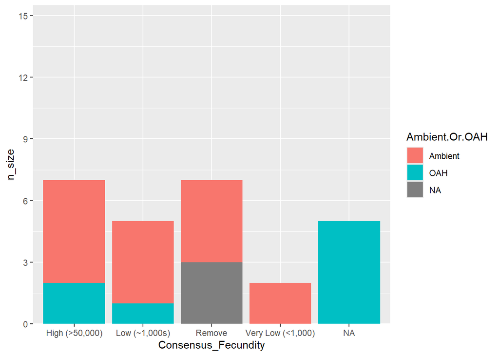

```r
# Test Vis
n_barplot <- ABL_merged %>%
  group_by(Consensus_Fecundity, Ambient.Or.OAH) %>%
  summarise(n_size = n_distinct(Patient.ID_edited), .groups = "drop") %>%
  ggplot(aes(x = Consensus_Fecundity, y = n_size, fill = Ambient.Or.OAH)) +
  geom_bar(stat = "identity" ) +
  scale_y_continuous(expand = c(0, 0), limits = c(0, 15.5), breaks = c(0, 3, 6, 9, 12, 15))

# +
#   facet_grid(Ambient.Or.OAH ~ Brood_Condition) +
#   labs(title = "Sample Size Of Parturition Status and Treatments On Maternal Gopher Rockfish",
#         x = "Parturition Outcome",
#         y = "Sample Size (n)") +
#   guides(fill = guide_legend((title = "Treatment Type"))) +
#   theme_classic(base_size = 10)

print(n_barplot)
```

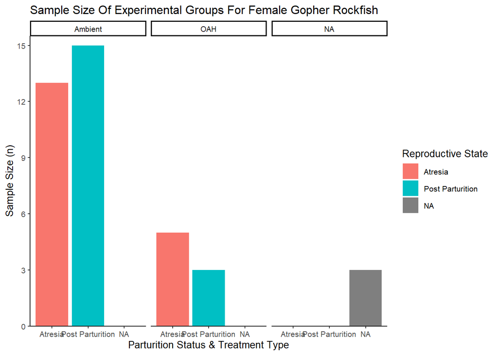

```r
# View Sample Distributions
sample_size_barplot <- ABL_merged %>%
  group_by(Pregnant.Or.Atresia, Ambient.Or.OAH) %>%
  summarise(n_size = n_distinct(Patient.ID_edited), .groups = "drop") %>%
  ggplot(aes(x = Pregnant.Or.Atresia, y = n_size, fill = Pregnant.Or.Atresia)) +
  geom_bar(stat = "identity" ) +
  scale_y_continuous(expand = c(0, 0), limits = c(0, 15.5), breaks = c(0, 3, 6, 9, 12, 15)) +
  facet_grid(~ Ambient.Or.OAH) +
  labs(title = "Sample Size Of Experimental Groups For Female Gopher Rockfish",
        x = "Parturition Status & Treatment Type",
        y = "Sample Size (n)") +
  guides(fill = guide_legend((title = "Reproductive State"))) +
  theme_classic(base_size = 10)

print(sample_size_barplot)
```

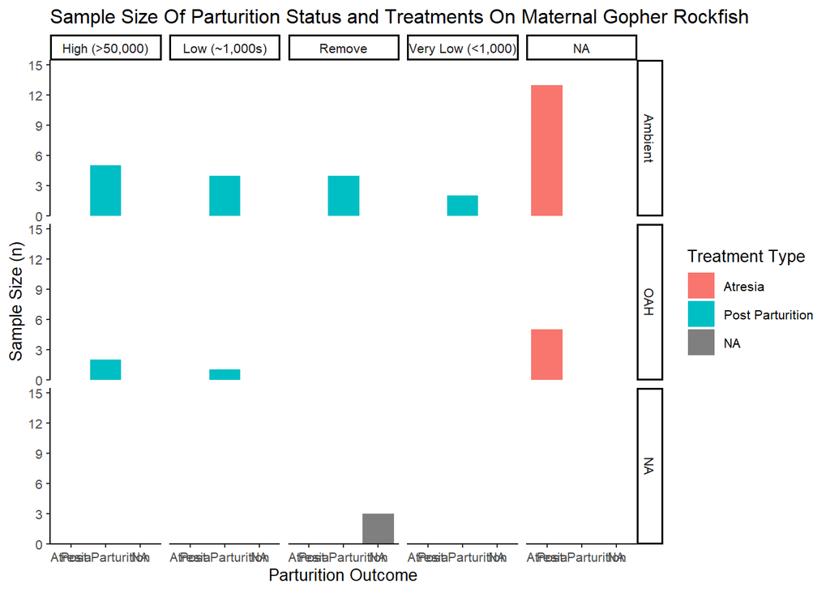

```r
ggsave(filename = "data-images/sample_size_barplot.png", plot = sample_size_barplot, device = "png")
ggsave(filename = "data-images/sample_size_barplot.pdf", plot = sample_size_barplot, device = "pdf")
# More detailed:
sample_size_barplot2 <- ABL_merged %>%
  group_by(Pregnant.Or.Atresia, Ambient.Or.OAH, Consensus_Fecundity) %>%
  summarise(n_size = n_distinct(Patient.ID_edited), .groups = "drop") %>%
  ggplot(aes(x = Pregnant.Or.Atresia, y = n_size, fill = Pregnant.Or.Atresia)) +
  geom_bar(stat = "identity" ) +
  scale_y_continuous(expand = c(0, 0), limits = c(0, 15.5), breaks = c(0, 3, 6, 9, 12, 15)) +
  facet_grid(Ambient.Or.OAH ~ Consensus_Fecundity) +
  labs(title = "Sample Size Of Parturition Status and Treatments On Maternal Gopher Rockfish",
        x = "Parturition Outcome",
        y = "Sample Size (n)") +
  guides(fill = guide_legend((title = "Treatment Type"))) +
  theme_classic(base_size = 10)

print(sample_size_barplot2)
```

```r
ggsave(filename = "data-images/sample_size_barplot2.png", plot = sample_size_barplot2, device = "png")
ggsave(filename = "data-images/sample_size_barplot2.pdf", plot = sample_size_barplot2, device = "pdf")
```